# Valorant Match Stats

What the stats say about your Valorant games

## How to kills compare to deaths?

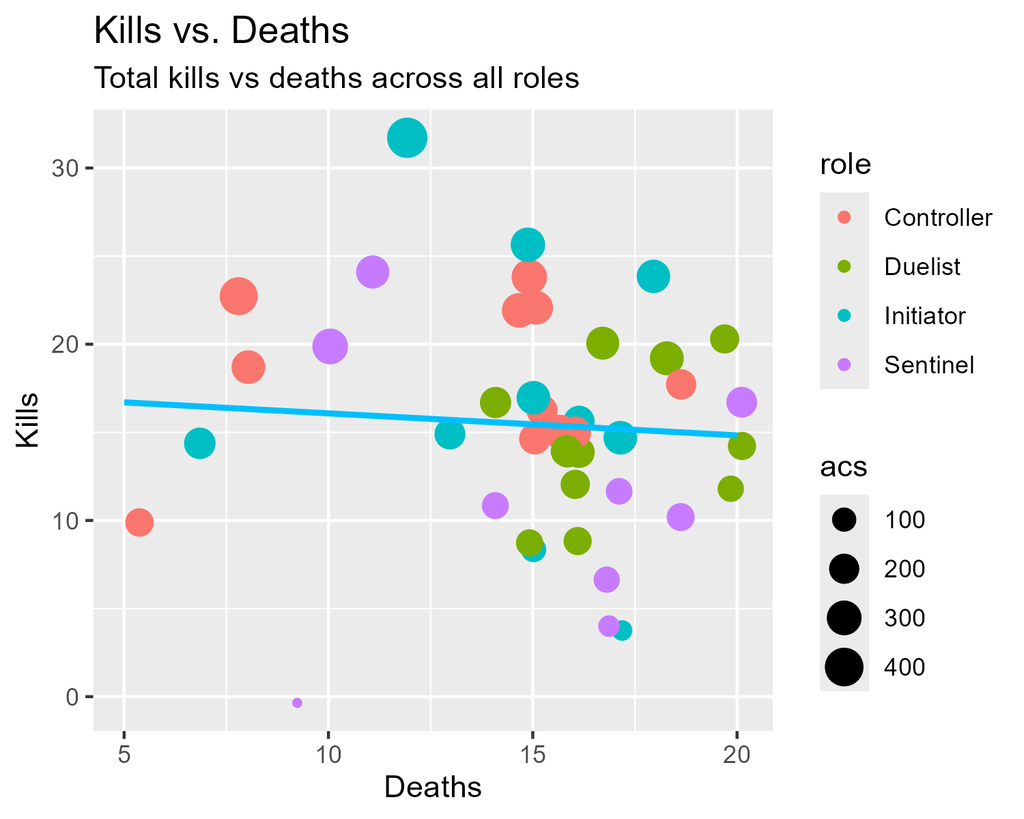

Dot plot of kills vs deaths

## This graph shows how kills compare to deaths. The size of the dot shows the ACS (average combat score) of that given match. The colour of the dot shows the role played in that given match. This graph is useful because it demonstrates how many deaths you should have at certain amounts of kills. At the time of writing, it appears normal to have very similar kills/deaths stats.

## How does KDR (Kill death ratio) compare to role?

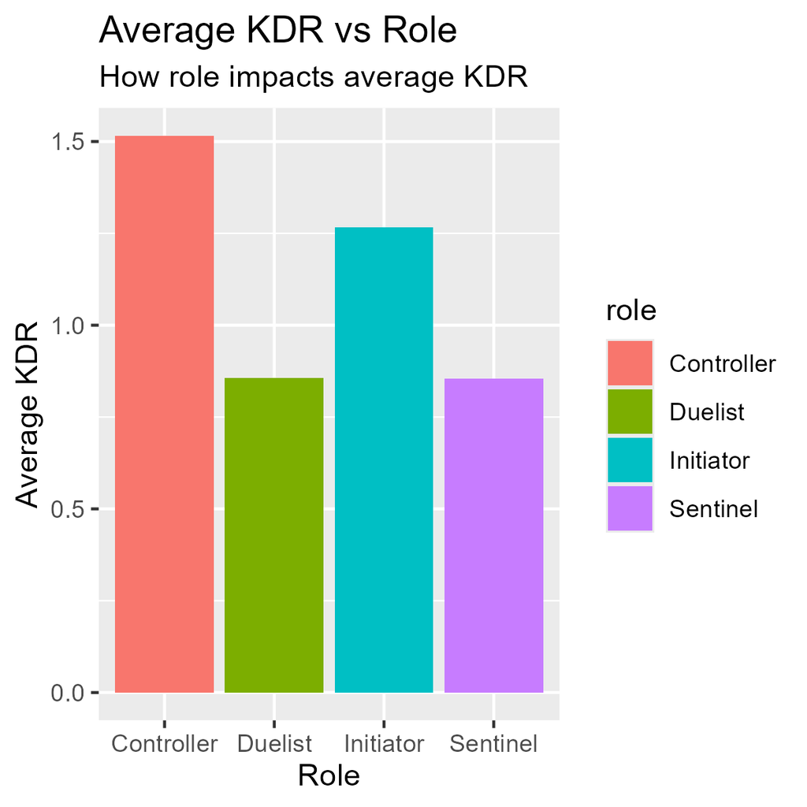

A graph comparing KDR and role played

## This graph shows how KDR (kill death ratio) is impacted by different roles.Typically, duelists should have the highest as they are designed to be very aggressive and to take many gunfights. At the time of writing, it would appear controller has the highest as they are able to sit in the back of a site and pick people off as they attempt to enter a site.

## How does outcome compare to games played before April 2026 and after April 2026?

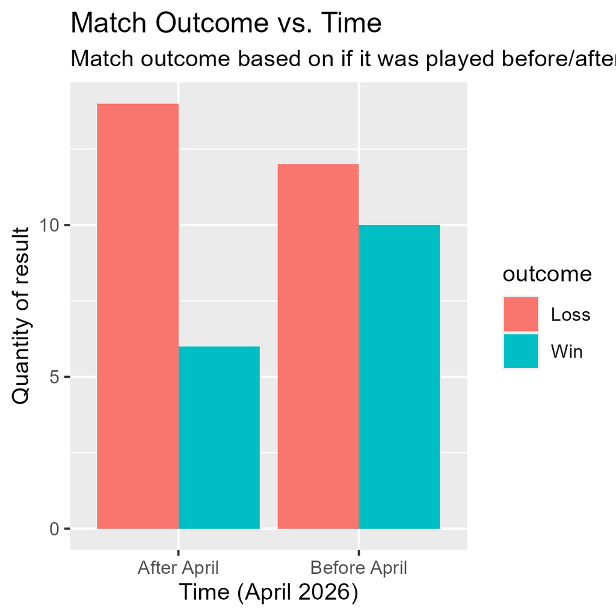

Graph showing how game outcome compares to time of match played

## This graph shows the results of games played before/after April 2026.